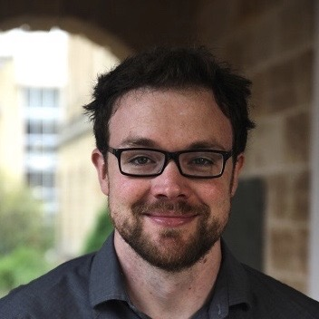

# Daniel Bradford PhD *(he/him/his)*

## Bio

I completed my undergrad at Auburn University, graduate work at the University of Wisconsin, Madison, and clinical internship at McLean Hospital/Harvard Medical School. In January 2020, I joined the Department of Psychology at the University of Miami as a new Assistant Professor where I provided clinical supervison to graduate student clinicians, taught graduate courses on statistics and experimental design, and undergraduate courses on addictive behaviors and research. In January 2022, I fully joined the School of Psychological Sciences at Oregon State University as an assistant professor in the Health Psychology program.

My program of research takes a multi-measure experimental psychopathology approach to better understand the role of stress reactivity in mental health. My research focuses on psychological processes at the interface of affect and addiction. My lab uses novel experimental tasks with precise manipulation of laboratory stressors, pharmacological challenges and psychophysiological measures that allow for tight translation between animal and human research. While our work is with people, our approach builds on preclinical findings in animals to identify specific stressor characteristics and neurobehavioral, cognitive, and affective mechanisms of reactivity to those stressors that are critical for understanding of stress reactivity in human psychopathology. This mechanistic understanding may provide novel targets for prevention and treatment of the adverse impacts of acute and chronic drug use as well as comorbid anxiety and depression.

I am also passionate about the empirical based refinement of psychophysiology methods and the improvement of clinical psychological science as a whole. As such, another branch of my research involves empirical studies designed to verify and increase the robustness, reliability, equity, and generalizability of psychophysiological tasks and measures, so researchers can continue to refine them to maximize their utility in studying affect and psychopathology with eventual goal of helping the most people. We also pre-register our studies and share our data processing and analysis code openly.

My personal interests include playing soccer and basketball as competitively as I can these days, and my dog Lucy.

## Education

**University of Wisconsin-Madison** | Madison, WI

Ph.D. | 2019

**McLean Hosptial / Harvard Medical School** | Belmont, MA

Clinical Internship | 2019

**University of Wisconsin-Madison** | Madison, WI

M.S. | 2009

**University of Auburn** | Auburn, AL

B.A. | 2007

## Interests

- Psychophysiology
- Open Science
- Stats
- Soccer
- Basketball
- My Great Pyrenees Mountain Dog, Lucy

See my tweets below:

[Tweets by Dr Bradford, Lab Director](https://twitter.com/drdanbradford?ref_src=twsrc%5Etfw)